# Konditional

Farhan Ameen and Ellis Patrick

School of Mathematics and Statistics, University of Sydney, Australia  
Westmead Institute for Medical Research, University of Sydney, Australia

7 October 2022

# Contents

```r
#Loading required packages
library(Statial)
library(tidyverse)
library(SingleCellExperiment)

theme_set(theme_classic())
```

# 1 Installation

```r
# Install the development version from GitHub:
# install.packages("devtools")
devtools::install_github("SydneyBioX/Statial")
```

# 2 Overview

`Konditional` is a method to evaluate the localisation relationship between two cell types in an image. Konditional builds on the L-function by contenualising the relationship between two cell types in reference to the typical spatial behaviour of a $3^{rd}$ cell type/population. By taking this approach, Konditional is invariant to changes in the window of the image as well as tissue structures which may be present.

# 3 Loading example data

In the following we will analyse some Head and Neck cancer data. These images are stored in a `SingleCellExperiment` object. The first step in analysing these images is to organise all the cells present into cell populations, e.g. all the B cells are put in a vector called bcells.

```r
# Load head and neck data
data("headSCE")

# Examine all cell types in image
unique(headSCE$cellType)
```

```
#>  [1] EC1       SC7       MC3       Undefined BC3       SC1       SC2
#>  [8] EP        SC4       BC2       TC_CD4    SC5       EC2       BC1
#> [15] SC3       MC2       GC        SC6       MC1       TC_CD8
#> 20 Levels: BC1 BC2 BC3 EC1 EC2 EP GC MC1 MC2 MC3 SC1 SC2 SC3 SC4 SC5 ... Undefined
```

```r
# Set up cell populations
tumour = c("SC1", "SC2", "SC3", "SC4", "SC5", "SC6", "SC7")

bcells = c("BC1", "BC2", "BC3")
tcells = c("TC_CD4", "TC_CD8")
myeloid = c("MC1", "MC2", "MC3")

endothelial = c("EC1", "EC2")
epithelial = c("EP")

tissue = c(endothelial, epithelial)
immune = c(bcells, tcells, myeloid, "GC") #GC = granulocytes

all = c(tumour, tissue, immune, "Undefined")
```

# 4 Konditional

Here we test the relationship between CD4 T cells (`TC_CD4`) and one type of Tumour cell (`SC5`) with all immune cells being our reference population. The output is a data frame with the original L-function values and konditional values as well as the values for the arguments specified.

```r
CD4_Konditional = Konditional(
    cells = headSCE,
    r = 50,
    from = "TC_CD4",
    to = "SC5",
    parent = immune,
    cores = 40
)

head(CD4_Konditional)
```

```
#>   imageID          test   original konditional  r weightQuantile inhom  edge
#> 1       1 TC_CD4 __ SC5 -11.504595  -13.471928 50            0.8  TRUE FALSE
#> 2      12 TC_CD4 __ SC5 -24.778403  -12.109163 50            0.8  TRUE FALSE
#> 3      13 TC_CD4 __ SC5 -13.971613  -10.144293 50            0.8  TRUE FALSE
#> 4      14 TC_CD4 __ SC5 -17.882760  -22.046105 50            0.8  TRUE FALSE
#> 5      15 TC_CD4 __ SC5  -1.849730    3.847290 50            0.8  TRUE FALSE
#> 6      16 TC_CD4 __ SC5  -7.733687    4.013349 50            0.8  TRUE FALSE
#>   includeZeroCells window window.length
#> 1             TRUE convex            NA
#> 2             TRUE convex            NA
#> 3             TRUE convex            NA
#> 4             TRUE convex            NA
#> 5             TRUE convex            NA
#> 6             TRUE convex            NA
```

The `original` and `konditional` values can be compared in a scatter plot to identify relationships which have been identified differently between the functions The top left quadrant represents values where `Konditional` has identified localisation between `CD4` and `SC5` and the original L-function has identified dispersion, the opposite is true for the bottom right quadrant.

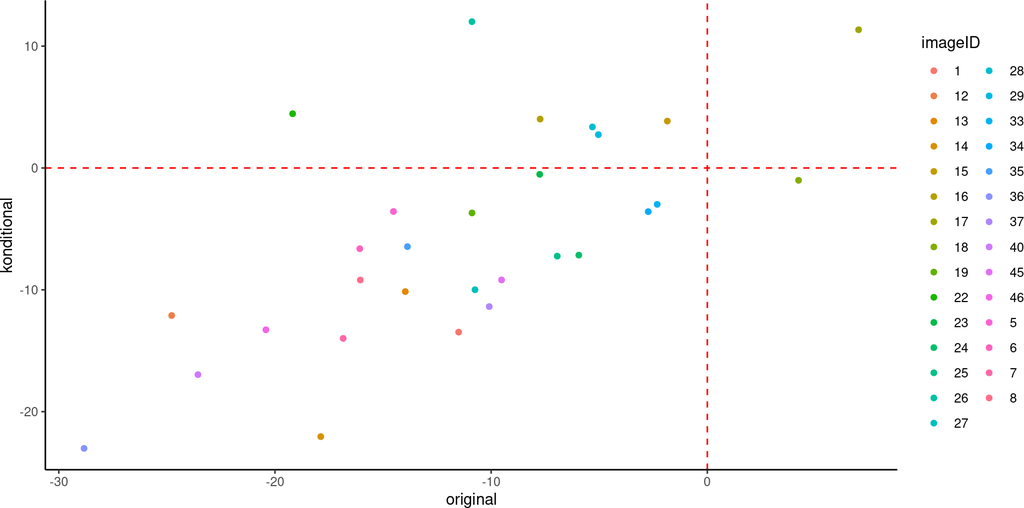

```r
ggplot(CD4_Konditional, aes(x = original, y = konditional, col = imageID)) +
    geom_point() +
    geom_hline(yintercept = 0, col = "red", linetype = "dashed") +
    geom_vline(xintercept = 0, col = "red", linetype = "dashed")
```

Alternatively all pairwise cell relationships and their corresponding parent in the dataset can be tested. A data frame with all pairwise combinations can be creating using the `parentCombinations` function. This function takes in a vector of all the cells, as well as all the parent vectors set up earlier. As shown below the output is a data frame specifying the `to`, `from`, and `parent` arguments for Kondtional.

```r
# Get all relationships between cell types and their parents
parentDf = parentCombinations(all = all,
                              tumour,
                              bcells,
                              tcells,
                              myeloid,
                              endothelial,
                              epithelial,
                              tissue,
                              immune)
head(parentDf)
```

```
#>   from  to       parent parent_name
#> 1  BC1 SC1 BC1, BC2....      bcells
#> 2  BC1 SC2 BC1, BC2....      bcells
#> 3  BC1 SC3 BC1, BC2....      bcells
#> 4  BC1 SC4 BC1, BC2....      bcells
#> 5  BC1 SC5 BC1, BC2....      bcells
#> 6  BC1 SC6 BC1, BC2....      bcells
```

Rather than specifying `to`, `from`, and `parent` in Konditional, the output from `parentCombinations` can be inputed into Konditional. Here we will test all pairwise cell relationships on the first image of the dataset.

```r
# Selecting Image 1 as an example
image_1 = headSCE %>% colData %>% data.frame() %>% filter(imageID == "1")


image1_Konditional = Konditional(cells = image_1,
                                 parentDf = parentDf,
                                 r = 50,
                                 cores = 40)
head(image1_Konditional)
```

```
#>   imageID                 test   original konditional  r weightQuantile inhom
#> 1       1 BC1 __ SC1 __ bcells  0.7630187    4.630450 50            0.8  TRUE
#> 2       1 BC1 __ SC2 __ bcells -7.4705926   -8.571246 50            0.8  TRUE
#> 3       1 BC1 __ SC3 __ bcells -9.3779345  -10.469486 50            0.8  TRUE
#> 4       1 BC1 __ SC4 __ bcells  1.1399765   -1.813705 50            0.8  TRUE
#> 5       1 BC1 __ SC5 __ bcells  6.9245893    5.263392 50            0.8  TRUE
#> 6       1 BC1 __ SC6 __ bcells -8.2848699   -4.657076 50            0.8  TRUE
#>    edge includeZeroCells window window.length
#> 1 FALSE             TRUE convex            NA
#> 2 FALSE             TRUE convex            NA
#> 3 FALSE             TRUE convex            NA
#> 4 FALSE             TRUE convex            NA
#> 5 FALSE             TRUE convex            NA
#> 6 FALSE             TRUE convex            NA
```

#RsCurve

Here we examine an image were the relationship between 2 cell types depends on a $3^{rd}$ cell population. This is a breast cancer image obtained from Keren et al, 2018 from patient 6. In the image below we can see that `p53` and `Immune` are dispersed, however when this relationship is placed in context of the large dispersion between `Keratin+Tumour` and `Immune`, now `p53` and `Immune` appear localised.

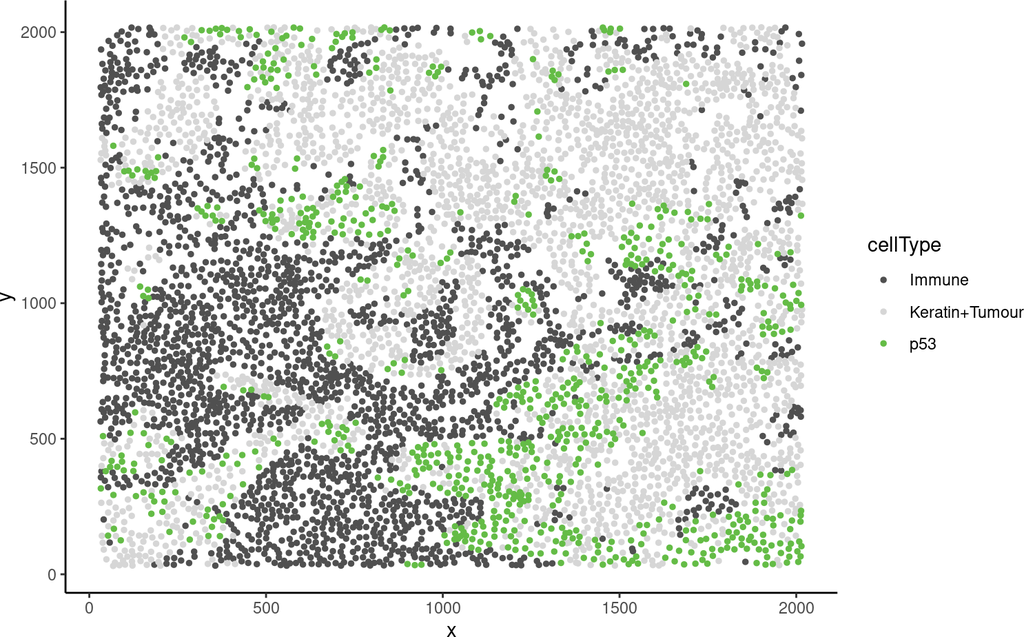

```r
data("kerenImage")

kerenImage %>% filter(cellType %in% c("Keratin+Tumour", "Immune", "p53")) %>%
    arrange(cellType) %>%
  ggplot(aes(x = x, y = y, color = cellType)) +
  geom_point(size = 1) +
  scale_colour_manual(values = c("#505050", "#D6D6D6", "#64BC46"))
```

The `rsCurve` function plots the L-function value and Konditional values over a range of radii. If the points lie above the red line (expected pattern) then localisation is indicated for that radius, if the points lie below the red line then dispersion is indicated. As seen in the following plot Konditional is able to correctly identify localisation between `p53` and `Immune` in the example image for a certain range of radii. When the radius gets too large the overall relationship between `p53` and `Immune` looks dispersed. The original L-function is not able to identify localisation at any value of radii.

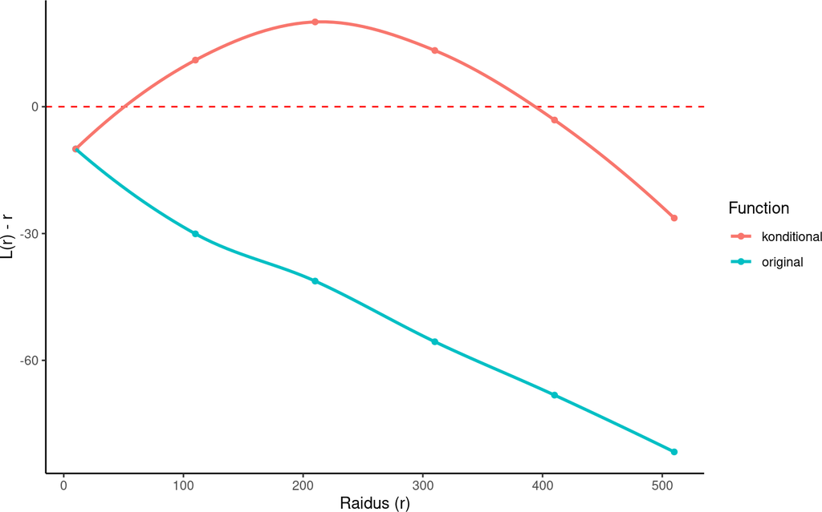

```r
rsDf = rsCurve(
    cells = kerenImage,
    from = "p53",
    to = "Immune",
    parent = c("p53", "Keratin+Tumour"),
    rs = seq(10, 510, 100),
    cores = 40
)


ggplotRs(rsDf)
```